# Hurdle_Data_Prep

Matt Webster

2026-07-28

The purpose of this RMarkdown document is to set up the dataframe for use in Ch1 models. Data herein is prepared for the folowing models:

```
Surface Water Hurdle Models:

  SW ~ damPresence
  SW ~ damPresence + geomorphic covar.
  SW ~ damDensity
  SW ~ damDensity + geomorphic covar.

Veg Area HGLMMs:

  VegArea ~ damPresence
  VegArea ~ damPresence + geomorphic covar.
  VegArea ~ damDensity
  VegArea ~ damDensity + geomorphic covar.

NDVI HGLMMs:

  NDVI ~ damPresence
  NDVI ~ damPresence + geomorphic covar.
  NDVI ~ damDensity
  NDVI ~ damDensity + geomorphic covar.
```

## USGS Flow Data

**Data from USGS LBV Guston Coulee gage, near Saco, MT:**

**Late Summer Flow Conditions**

**2019:**

Moderate August with small peak in September

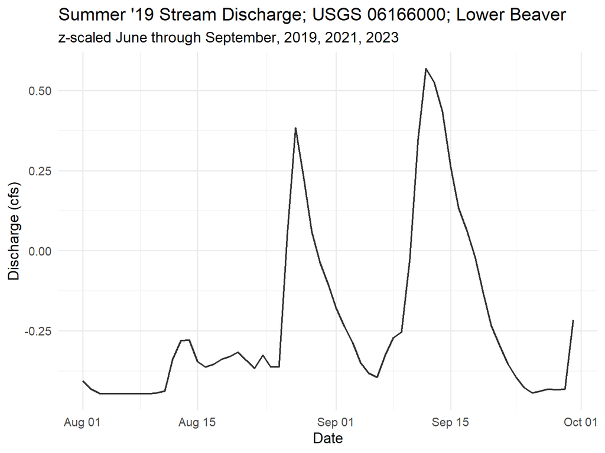

**2021:**

Low flow conditions throughout the summer season. Part of 3 year sustained drought conditions (2020, 2021, 2022).

Gage recorded no flow during August & September

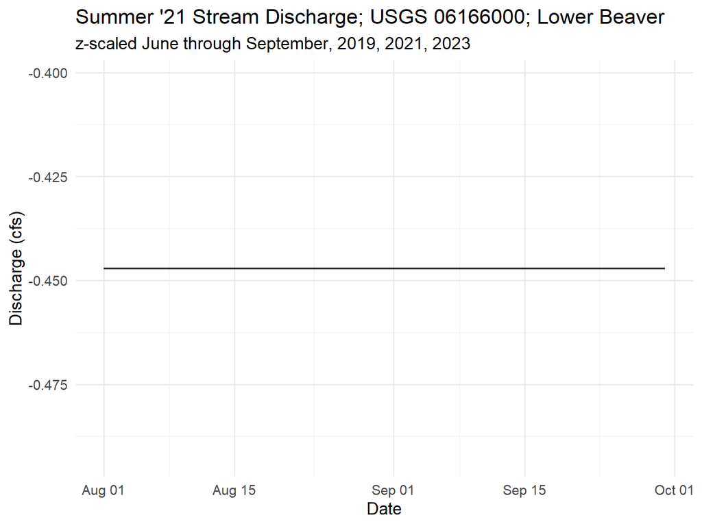

**2023:**

Moderate to low August & September flows; after early season extreme flooding.

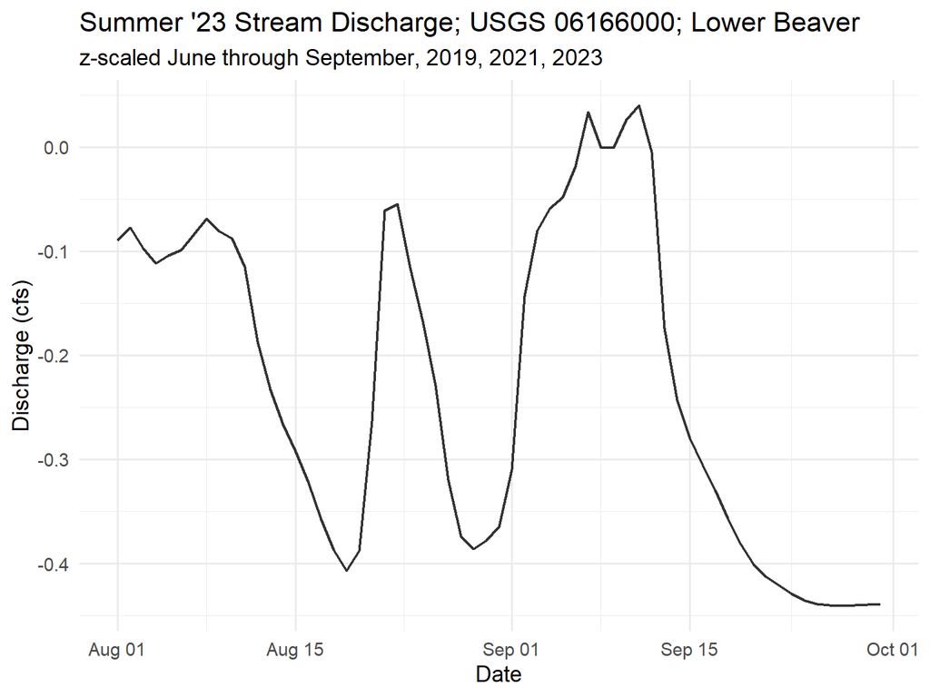

## GEE-derived data for each stream:

Where:

```
- clusterID_seq = dammed/undammed sample pair ID
- window_type = whether a sample window is 'dammed' or 'undammed'
- watershed = watershed identifier (e.g., "BRZ" = Brazil Ck)
- year = year
- window_length = length (m) of stream flow line within sample window
- catchment_km2 = contributing catchment area/upstream drainage area (km^2)
- riparian_area_m2 = riparian area (m^2) of sample window; 2-m vertical
  buffer from DEM low point (stream flow line)
- TO = mean topographic openness across window
- p_window: avg dam detection prob for target window; see CP Ch1
- f_window: avg dam false positive prob for target window; see CP Ch1
- beav_count_all: all unique detected dams
- beav_count_conf: unique confidently detected dams
- anthro_count: all unique detected anthropogenic dams
- isAnthro: National Wetland Inventory (NWI) "dyked/impounded"
- Nhat = estimated dam count within sample window
  - ...= beav_count_all/(p_window(1-f_window)  [McCallum 2005]
- TO_mean = mean topographic openness across window
- time_period = 2wk interval 06/01 - 09/30
- SWA = surface water area (m^2) for window during time (t)
- t = time (t) {same as time_period}
```

## Format data for hurdle:

```r
# Create binary indicator of surface water presence, for logistic part of hurdle model:
aoi_HurdleData <- aoi_glm_data_mod_refined

aoi_HurdleData$y <- ifelse(aoi_glm_data_mod_refined$SWA>0,1,0)
aoi_HurdleData$y_veg <- ifelse(aoi_glm_data_mod_refined$VA>0,1,0)
aoi_HurdleData$dam_km_std <- scale(aoi_HurdleData$dam_km)

str(aoi_HurdleData)
```

```
## 'data.frame':    2445 obs. of  25 variables:
##  $ clusterID_seq   : int  1 1 1 1 1 1 1 1 3 3 ...
##  $ window_type     : chr  "dammed" "dammed" "dammed" "dammed" ...
##  $ watershed       : chr  "WC" "WC" "WC" "WC" ...
##  $ year            : num  2019 2019 2019 2019 2019 ...
##  $ catchment_km2   : num  1394 1394 1394 1394 1391 ...
##  $ TO              : num  34.2 34.2 34.2 34.2 35.7 ...
##  $ Nhat            : num  1.13 1.13 1.13 1.13 0 ...
##  $ t               : int  5 6 7 8 5 6 7 8 5 6 ...
##  $ surveyPeriod    : Factor w/ 24 levels "195","196","197",..: 1 2 3 4 1 2 3 4 1 2 ...
##  $ SWA             : num  106.7 0 94.6 2382 66.7 ...
##  $ VA              : num  16274 17732 16901 4812 14708 ...
##  $ NDVI            : num  0.361 0.359 0.349 0.358 0.364 ...
##  $ riparian_area_m2: num  2678 2678 2678 2678 2766 ...
##  $ dam_km          : num  4.53 4.53 4.53 4.53 0 ...
##  $ clusterID_unique: Factor w/ 338 levels "2019.BRZ.1","2021.BRZ.1",..: 16 16 16 16 16 16 16 16 34 34 ...
##  $ clusterID_num   : num  16 16 16 16 16 16 16 16 34 34 ...
##  $ stream          : num  6 6 6 6 6 6 6 6 6 6 ...
##  $ sampleEvent     : num  1 2 3 4 1 2 3 4 1 2 ...
##  $ year_id         : num  1 1 1 1 1 1 1 1 1 1 ...
##  $ damPresence     : num  1 1 1 1 0 0 0 0 1 1 ...
##  $ sampleEvent_new : int  1 2 3 4 1 2 3 4 1 2 ...
##  $ logSWA          : num  4.68 0 4.56 7.78 4.21 ...
##  $ y               : num  1 0 1 1 1 1 1 1 1 1 ...
##  $ y_veg           : num  1 1 1 1 1 1 1 1 1 1 ...
##  $ dam_km_std      : num [1:2445, 1] 0.499 0.499 0.499 0.499 -0.94 ...
##   ..- attr(*, "scaled:center")= num 2.96
##   ..- attr(*, "scaled:scale")= num 3.15
```

```r
# write.csv(aoi_HurdleData,"aoi_HurdleData.csv")
```

**Visualize SWA distribution:**

**Raw SWA (m^2):**

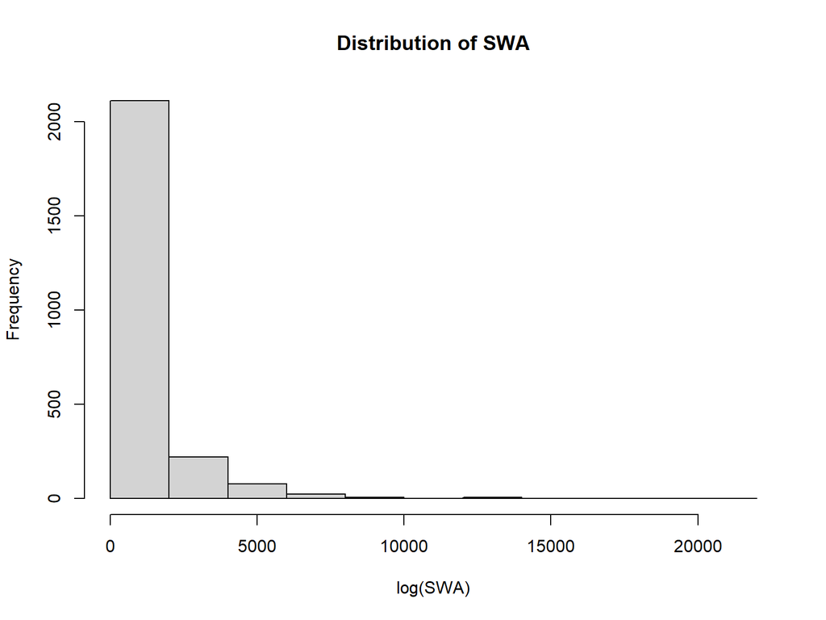

**Log-transform SWA to ‘normalize’ the right skew:**

**log(SWA):**

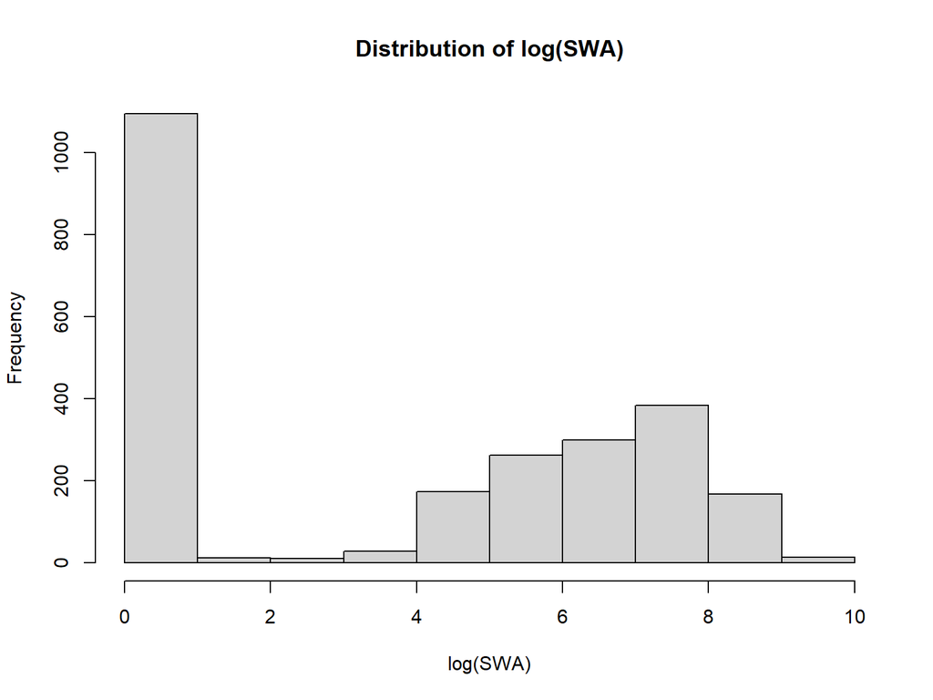

This persistent spike at 0 is why we’re using the hurdle approach for SWA. First model SW(0,1); then for SW = 1 model SWA.

**Visualize veg area (VA) distribution**

**Raw VA (m^2):**

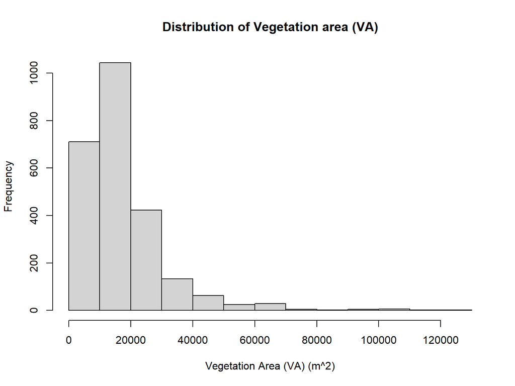

**Log-transform VA to normalize the right skew:**

**log(VA):**

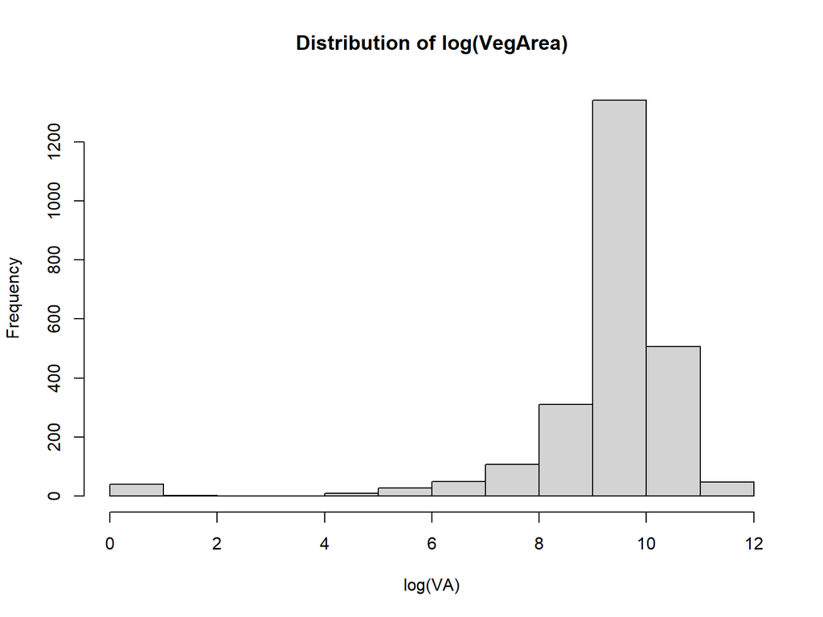

Long tail, but no spike at 0. Will model log(vegArea) ~ damPres + …

**Visualize NDVI distribution**

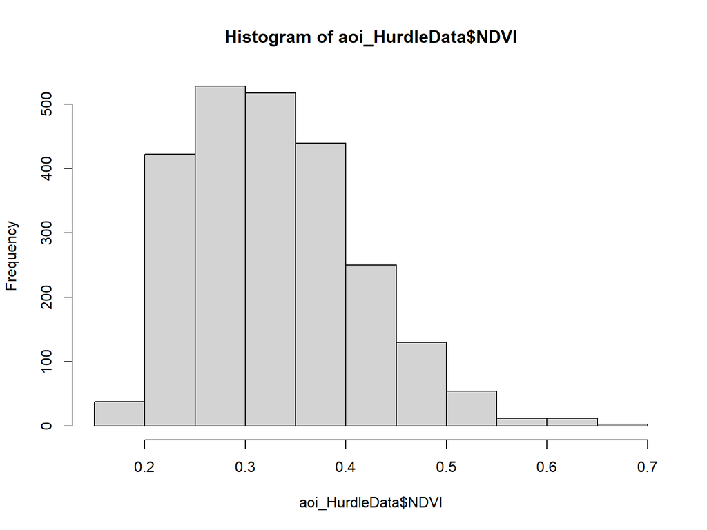

Pretty much normal. No transformation needed

**Check out variation in (response)~damEffect among grouping variables (stream,year,event):**

Graphs are produced using “geom_smooth(method =”lm”, formula = y ~ x)“, which plots/fits a simple linear regression to the y~x scatterplot.

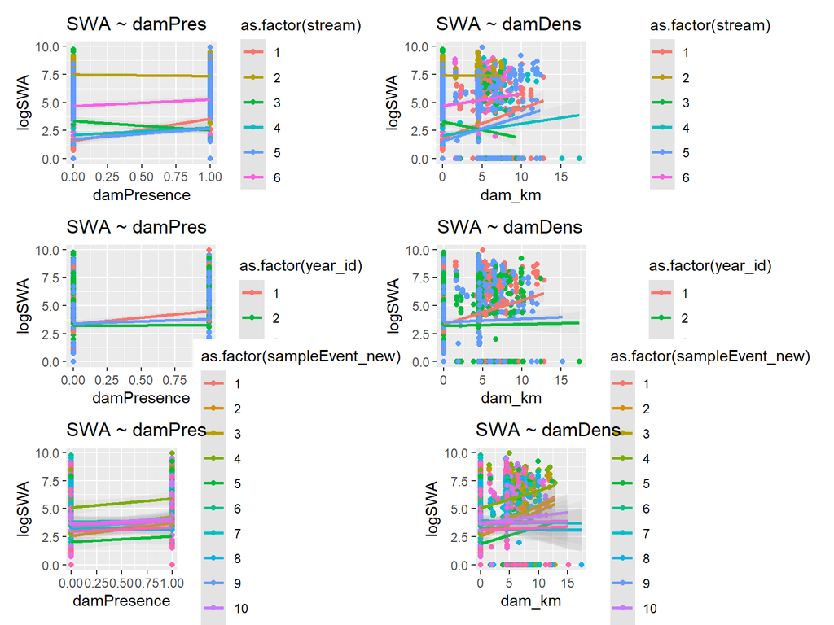

```
Variation in SWA among group-levels suggest that random intercepts and slopes
are warranted.
```

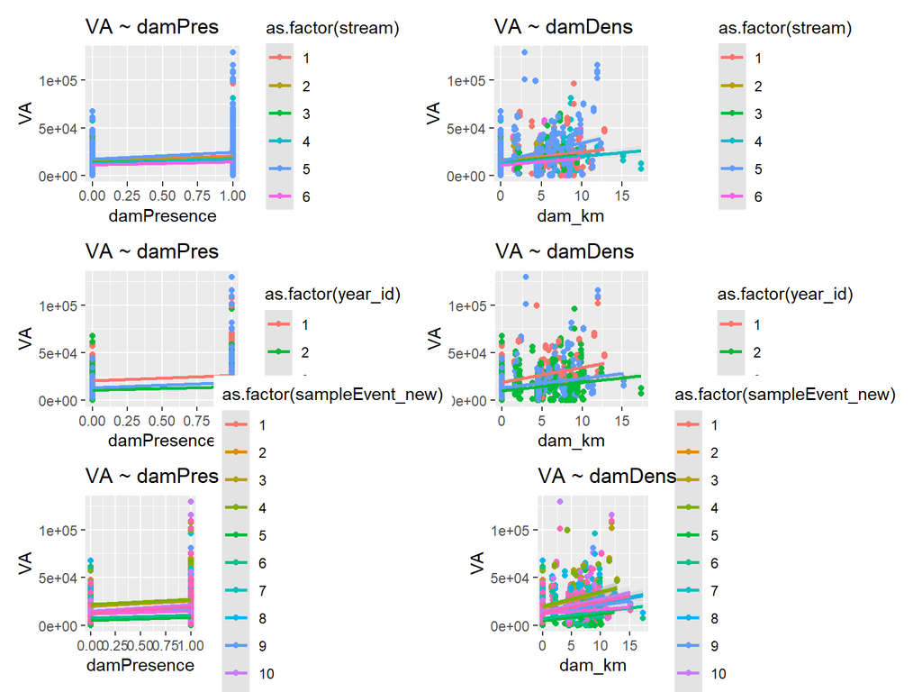

```
Variation in VA among group-levels suggests that random intercepts may be supported,
but it is unlikely that random slopes are reasonable. Inclusion leads to unidentifiability.
```

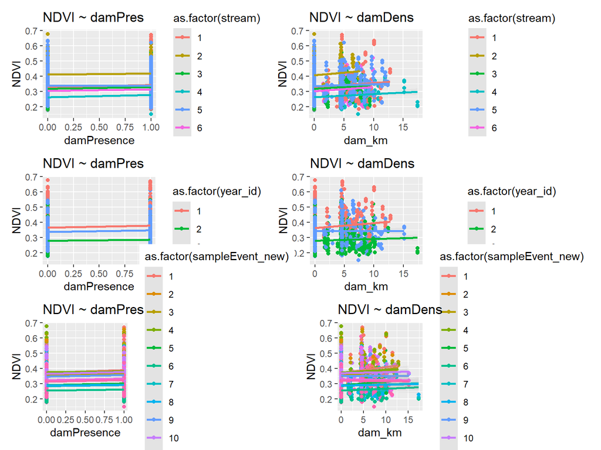

```
Variation in NDVI among group-levels suggest that random intercepts may
be supported, but it is unlikely that random slopes are reasonable. Inclusion
leads to unidentifiability. Also suggests little to no structural difference in
NDVI by sample event. (No real seasonal difference in NDVI for Aug-Sep)
```

```
Proposed approach:

log(SW) ~ dam: hurdle model with random intercepts and slopes

log(VA) ~ dam: HGLMM with random  intercepts only

NDVI ~ dam: HGLMM with random intercepts only
```